# Mentoria de introdução às possibilidades do pacote ggplot2

## Remover apenas uma entrada de legenda:

Aqui vamos remover a legenda para as cores e manter a leganda para as formas ajustando *guides(color = “none”)*

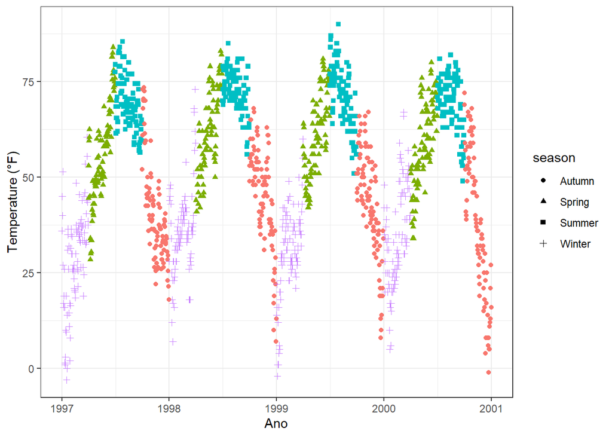

```r
ggplot(chic,
       aes(x = date, y = temp,
           color = season, shape = season)) +
  geom_point() +
  labs(x = "Ano", y = "Temperature (°F)") +
  guides(color = "none")
```

## Remover o título da legenda:

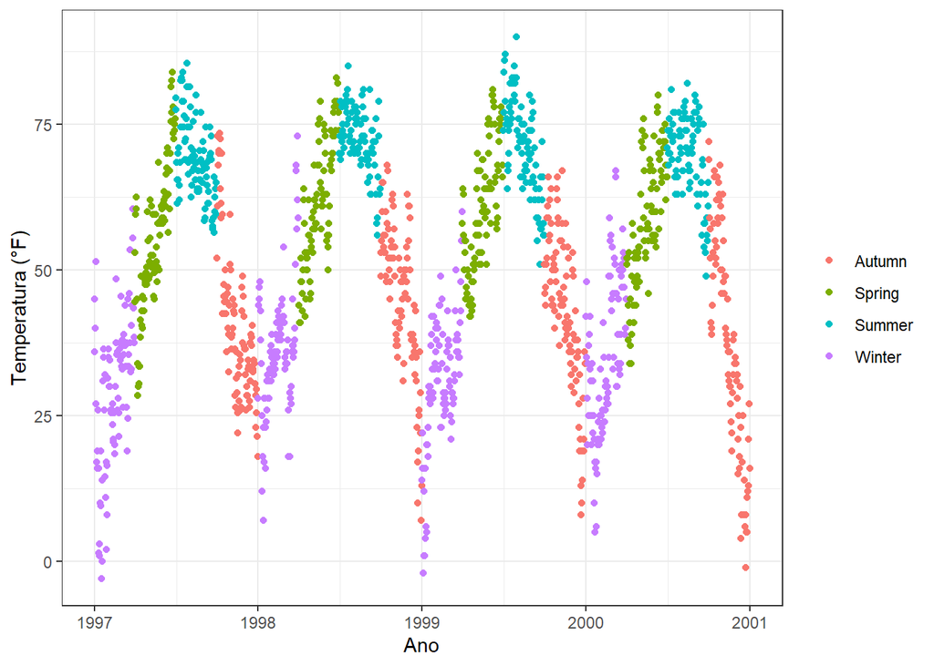

```r
ggplot(chic, aes(x = date, y = temp, color = season)) +
  geom_point() +
  labs(x = "Ano", y = "Temperatura (°F)") +
  theme(legend.title = element_blank())
```

## Posição da legenda:

Temos algumas opções:

- *top*
- *right* (esse é o default)
- *bottom*
- *left*

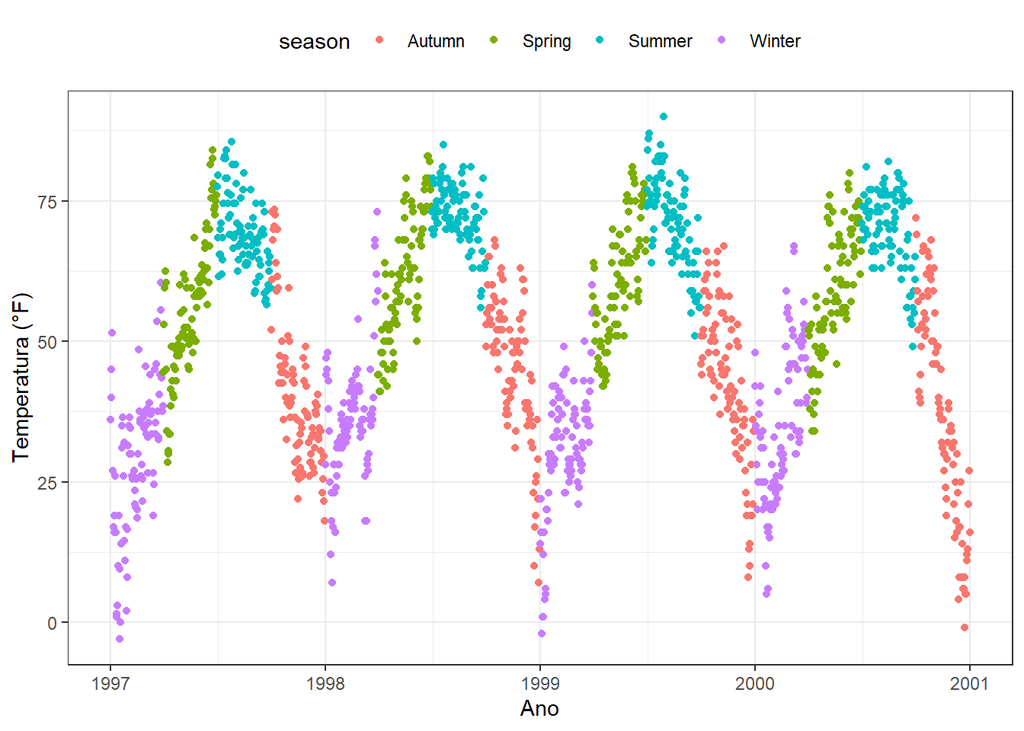

```r
ggplot(chic, aes(x = date, y = temp, color = season)) +
  geom_point() +
  labs(x = "Ano", y = "Temperatura (°F)") +
  theme(legend.position = "top")
```

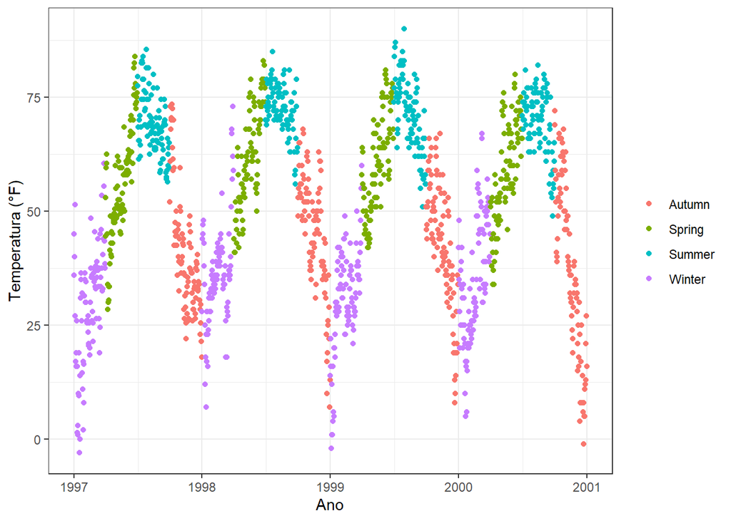

```r
ggplot(chic, aes(x = date, y = temp, color = season)) +
  geom_point() +
  labs(x = "Ano", y = "Temperatura (°F)",
       color = NULL) +
  theme(legend.position.inside = c(.15, .15),
        legend.background = element_rect(fill = "transparent"))
```

## Direção da legenda:

No exemplo a seguir deixamos a legenda na direção horizontal

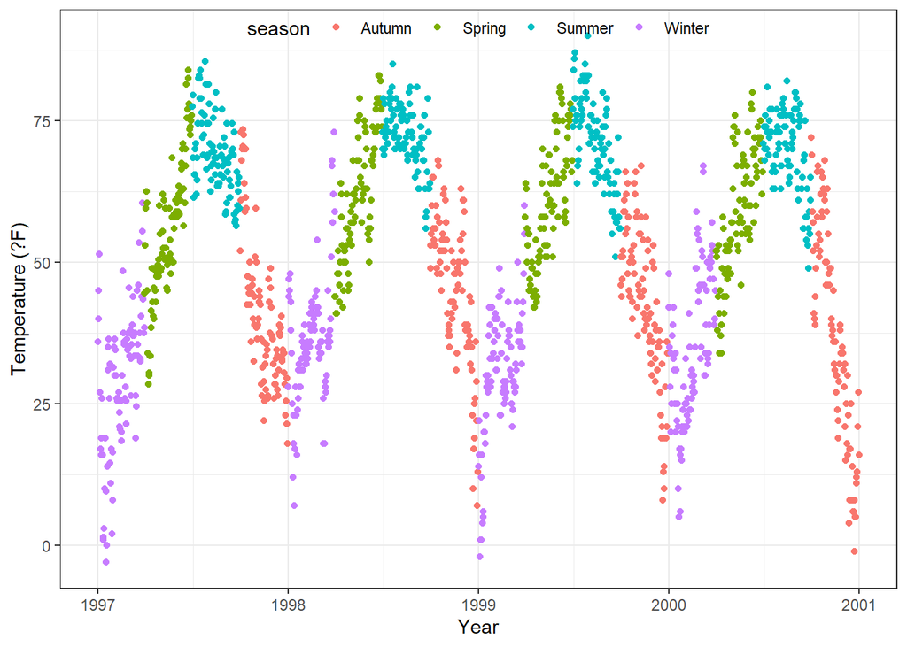

```r
ggplot(chic, aes(x = date, y = temp, color = season)) +
  geom_point() +
  labs(x = "Year", y = "Temperature (?F)") +
  theme(legend.position = c(.5, .97),
        legend.background = element_rect(fill = "transparent")) +
  guides(color = guide_legend(direction = "horizontal"))
```

## Estilo do título da legenda:

Para alteraro estílo do título da legenda adicionamos o argumento *legend.title* em *theme()*

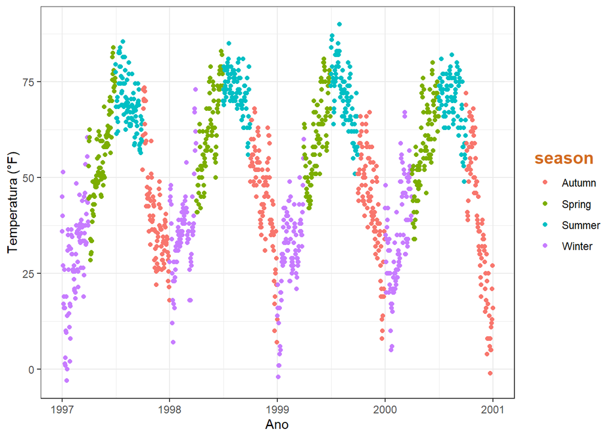

```r
# theme(legend.title = ())

ggplot(chic, aes(x = date, y = temp, color = season)) +
  geom_point() +
  labs(x = "Ano", y = "Temperatura (°F)") +
  theme(legend.title = element_text(color = "chocolate",
                                    size = 14, face = "bold"))
```

Além disso é possível mudar o texto do título da legenda

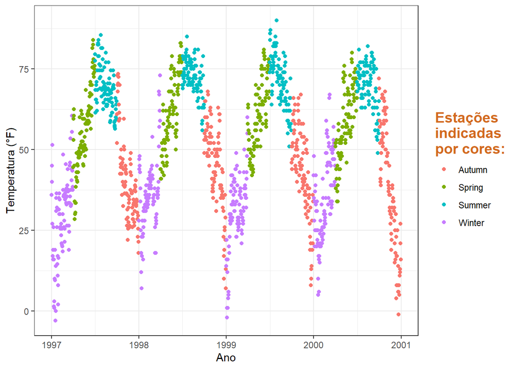

```r
ggplot(chic, aes(x = date, y = temp, color = season)) +
  geom_point() +
  labs(x = "Ano", y = "Temperatura (°F)",
       color = "Estações\nindicadas\npor cores:") +
  theme(legend.title = element_text(color = "chocolate",
                                    size = 14, face = "bold"))
```

```r
# aqui \n é usado para qiebra de texto
```

## Alterar a ordem dos itens da legenda:

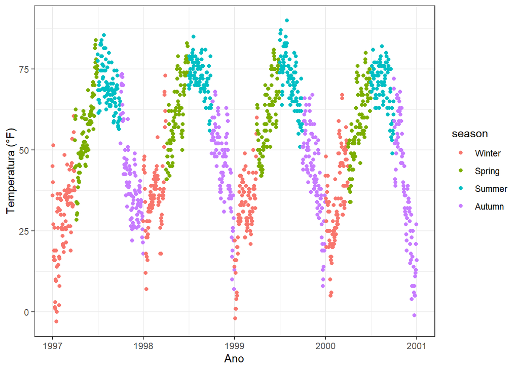

```r
# determinar a ordem dos níveis antes da plotagem

chic$season <-
  factor(chic$season,
         levels = c("Winter", "Spring", "Summer", "Autumn"))


# plotar

ggplot(chic, aes(x = date, y = temp, color = season)) +
  geom_point() +
  labs(x = "Ano", y = "Temperatura (°F)")
```

## Alterar os nomes dos níveis da legenda:

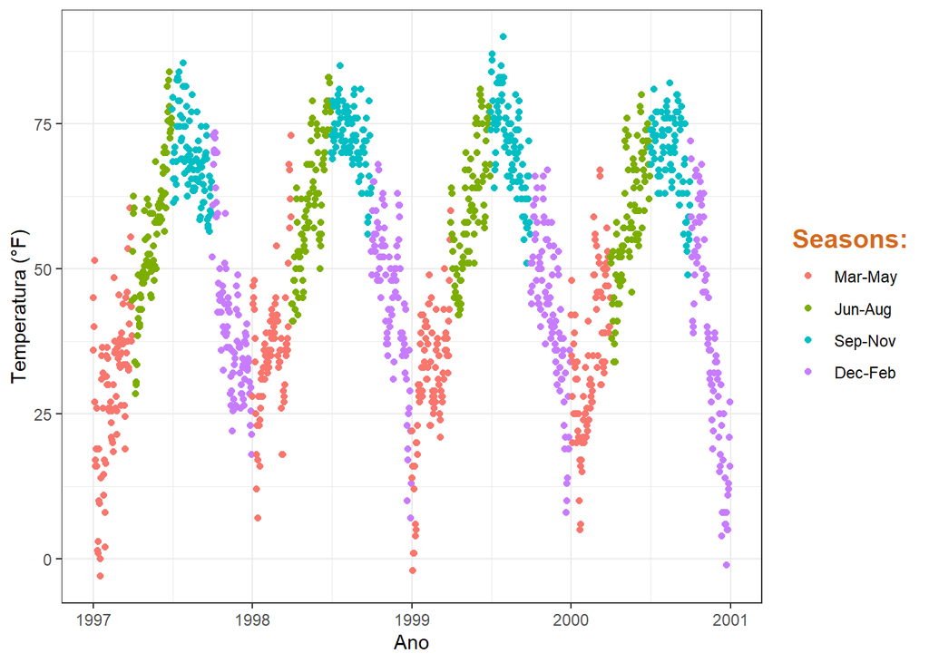

```r
# scale_color_discrete()

ggplot(chic, aes(x = date, y = temp, color = season)) +
  geom_point() +
  labs(x = "Ano", y = "Temperatura (°F)") +
  scale_color_discrete(
    name = "Seasons:",
    labels = c("Mar-May", "Jun-Aug", "Sep-Nov", "Dec-Feb")
  ) +
  theme(legend.title = element_text(
     color = "chocolate", size = 14, face = 2
  ))
```

## Alterar o preenchimento dos itens da legenda:

Como opção estética, você pode colocar cores de preenchimento nos ítens da legenda

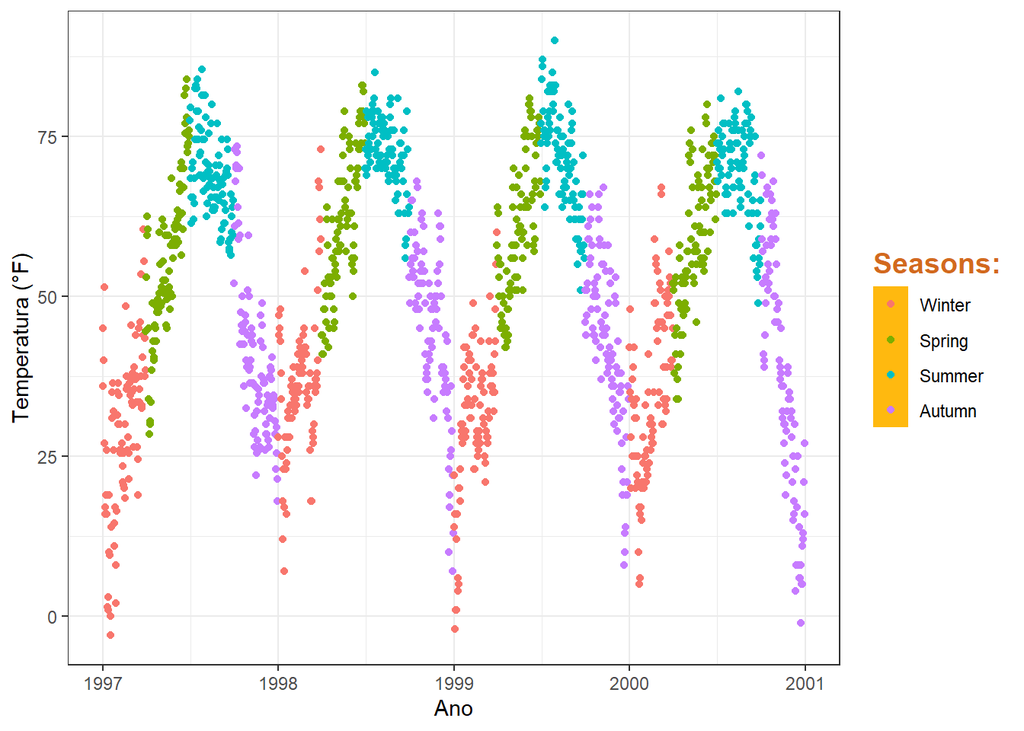

```r
# legend.key()

ggplot(chic, aes(x = date, y = temp, color = season)) +
  geom_point() +
  labs(x = "Ano", y = "Temperatura (°F)") +
  theme(legend.key = element_rect(fill = "darkgoldenrod1"),
        legend.title = element_text(color = "chocolate",
                                    size = 14, face = 2)) +
  scale_color_discrete("Seasons:")
```

Ou remover o preenchimento

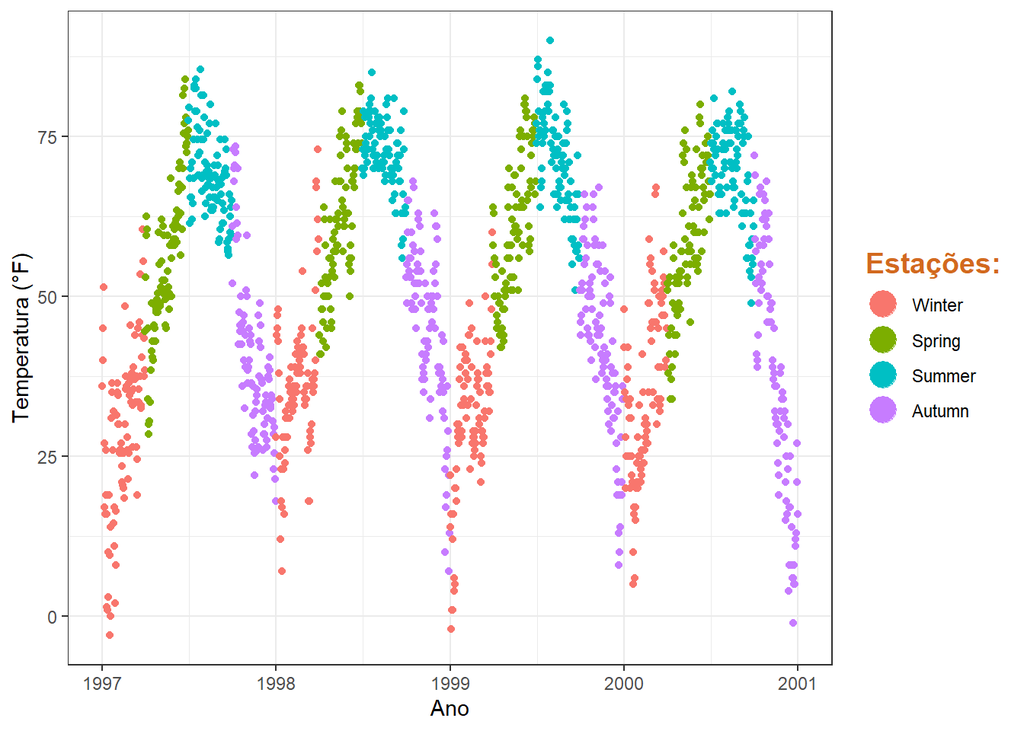

```r
# sem preenchimento:
# fill = NA or fill = "transparent"

# alterar o tamanho dos simbolos da legenda:
ggplot(chic, aes(x = date, y = temp, color = season)) +
  geom_point() +
  labs(x = "Ano", y = "Temperatura (°F)") +
  theme(legend.key = element_rect(fill = NA),
        legend.title = element_text(color = "chocolate",
                                    size = 14, face = 2)) +
  scale_color_discrete("Estações:") +
  guides(color = guide_legend(override.aes = list(size = 6)))
```

## Outros estilos de legenda (gradiente):

Quando estamos mapeando uma variável contínua, o *ggplot* por default determina um gradiente

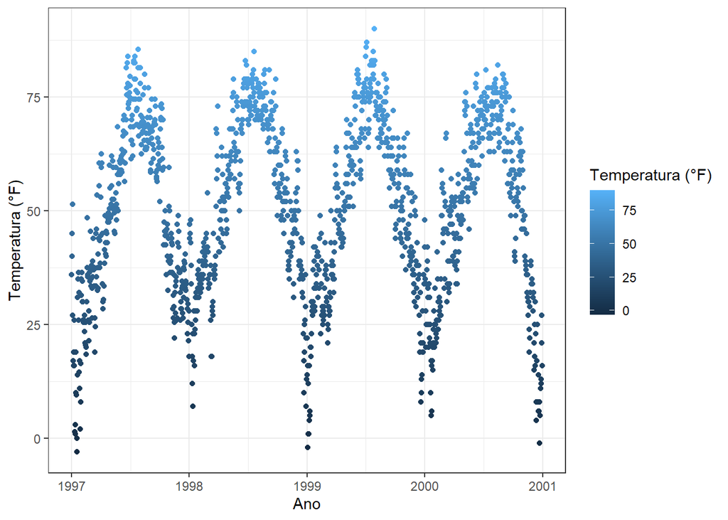

```r
ggplot(chic,
       aes(x = date, y = temp, color = temp)) +
  geom_point() +
  labs(x = "Ano", y = "Temperatura (°F)", color = "Temperatura (°F)")
```

Mas podemos forçar a legenda a mostrar valores discretos com *guide_legend()*

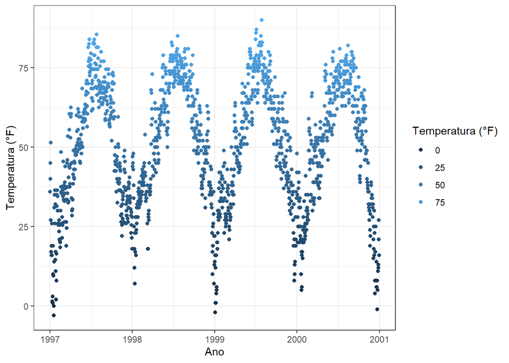

```r
ggplot(chic,
       aes(x = date, y = temp, color = temp)) +
  geom_point() +
  labs(x = "Ano", y = "Temperatura (°F)", color = "Temperatura (°F)") +
  guides(color = guide_legend())
```

Também podemos limtar as escalas

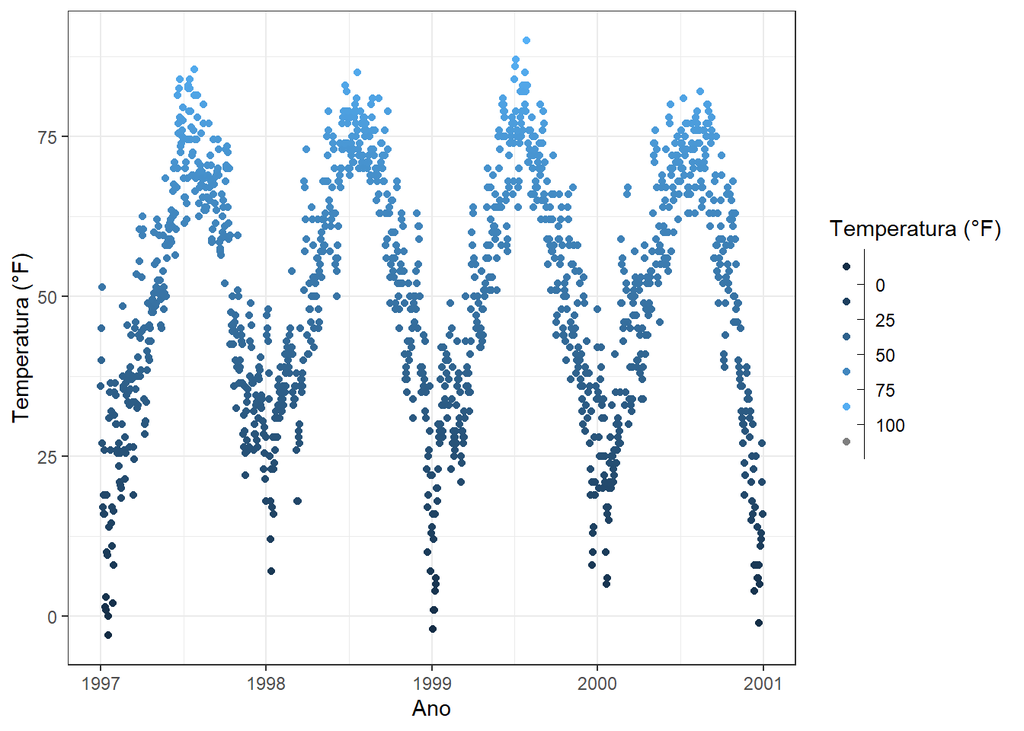

```r
ggplot(chic,
       aes(x = date, y = temp, color = temp)) +
  geom_point() +
  labs(x = "Ano", y = "Temperatura (°F)", color = "Temperatura (°F)") +
  guides(color = guide_bins())
```

Ou utilizar uma escala de cores discretas:

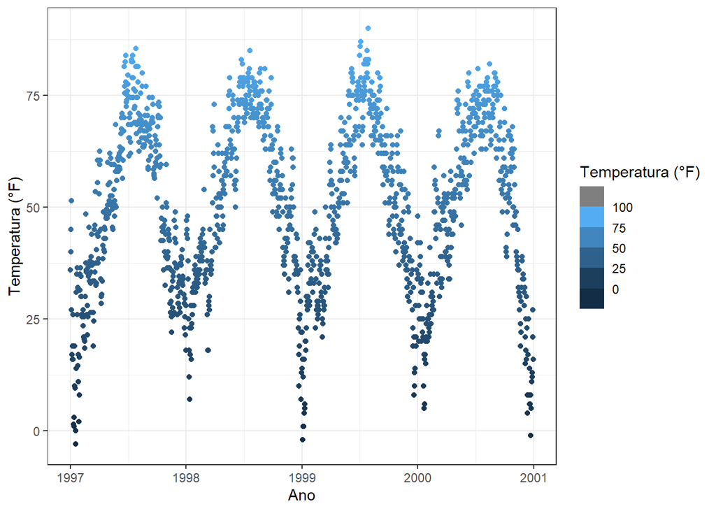

```r
ggplot(chic,
       aes(x = date, y = temp, color = temp)) +
  geom_point() +
  labs(x = "Ano", y = "Temperatura (°F)", color = "Temperatura (°F)") +
  guides(color = guide_colorsteps())
```

# Planos de fundo e linhas:

Planos de fundo e linhas podem ser alterados dentro da função *theme()*

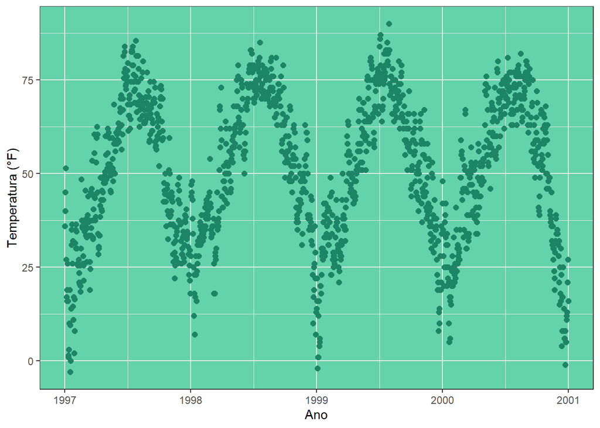

```r
ggplot(chic, aes(x = date, y = temp)) +
  geom_point(color = "#1D8565", size = 2) +
  labs(x = "Ano", y = "Temperatura (°F)") +
  theme(panel.background = element_rect(
    fill = "#64D2AA", color = "#64D2AA", linewidth = 2)
  )
```

## Alterando a borda

Observe que a cor verdadeira - o contorno do fundo do painel - não vai mudar nesse exemplo, mesmo que a tenhamos especificado. Isso ocorre porque há uma camada em cima de *painel.background*, ou seja, *painel.border*

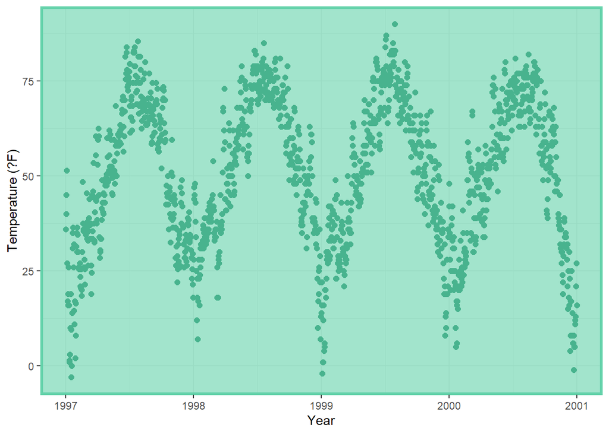

```r
ggplot(chic, aes(x = date, y = temp)) +
  geom_point(color = "#1D8565", size = 2) +
  labs(x = "Year", y = "Temperature (?F)") +
  theme(panel.border = element_rect(
    fill = "#64D2AA99", color = "#64D2AA", size = 2)
  )
```

## Alterar linhas:

Para alterar as çinhas usamos *panel.grid()* ou, para cada conjunto de linhas separadamente: *panel.grid.major()* e *panel.grid.minor()*

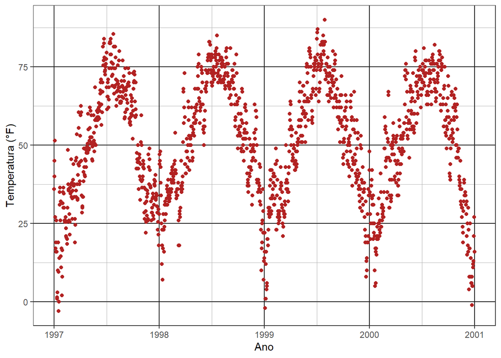

```r
ggplot(chic, aes(x = date, y = temp)) +
  geom_point(color = "firebrick") +
  labs(x = "Ano", y = "Temperatura (°F)") +
  theme(panel.grid.major = element_line(color = "gray10", linewidth = .5),
        panel.grid.minor = element_line(color = "gray70", linewidth = .25))
```

Podemos também detalhas mais

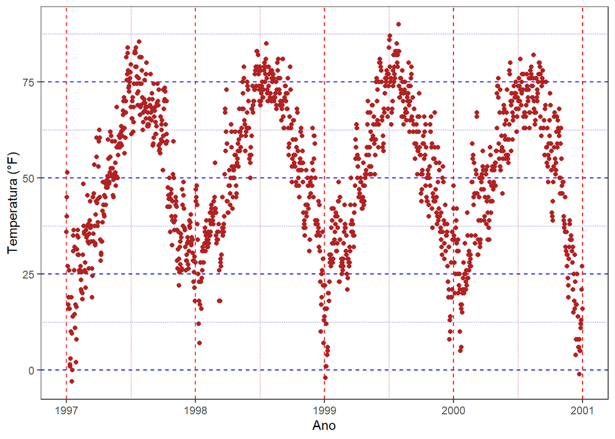

```r
ggplot(chic, aes(x = date, y = temp)) +
geom_point(color = "firebrick") +
  labs(x = "Ano", y = "Temperatura (°F)") +
  theme(panel.grid.major = element_line(size = .5, linetype = "dashed"),
        panel.grid.minor = element_line(size = .25, linetype = "dotted"),
        panel.grid.major.x = element_line(color = "red1"),
        panel.grid.major.y = element_line(color = "blue1"),
        panel.grid.minor.x = element_line(color = "red4"),
        panel.grid.minor.y = element_line(color = "blue4"))
```

Podemos também remover as linhas

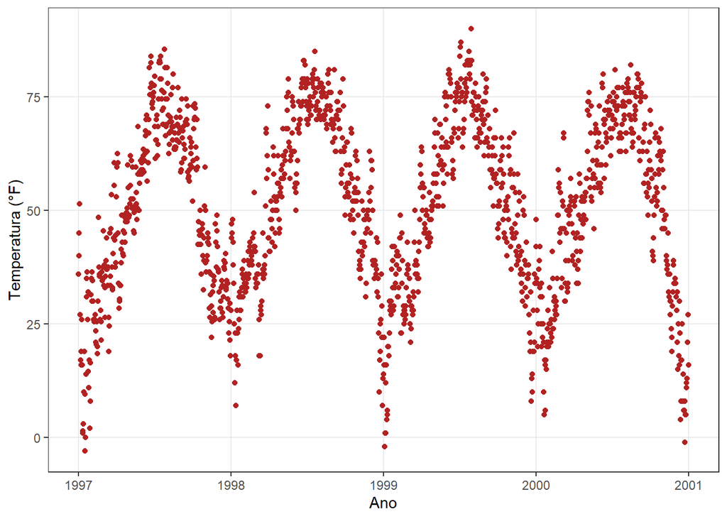

```r
ggplot(chic, aes(x = date, y = temp)) +
  geom_point(color = "firebrick") +
  labs(x = "Ano", y = "Temperatura (°F)") +
  theme(panel.grid.minor = element_blank())
```

Todas as linhas

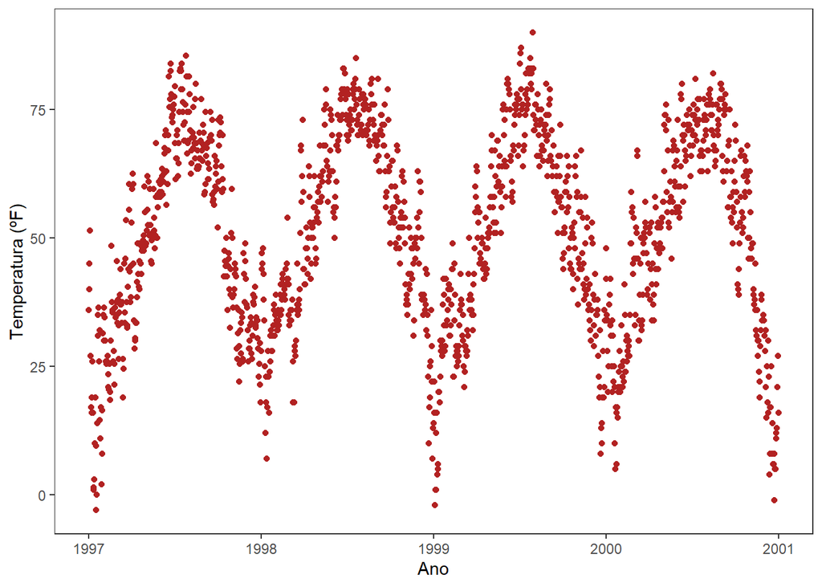

```r
ggplot(chic, aes(x = date, y = temp)) +
  geom_point(color = "firebrick") +
  labs(x = "Ano", y = "Temperatura (ºF)") +
  theme(panel.grid = element_blank())
```

```r
# ou theme_minimal()
```

## Alterar a cor do fundo:

Aqui podemos modificar com *panel.background()* e *plot.backgroun()*

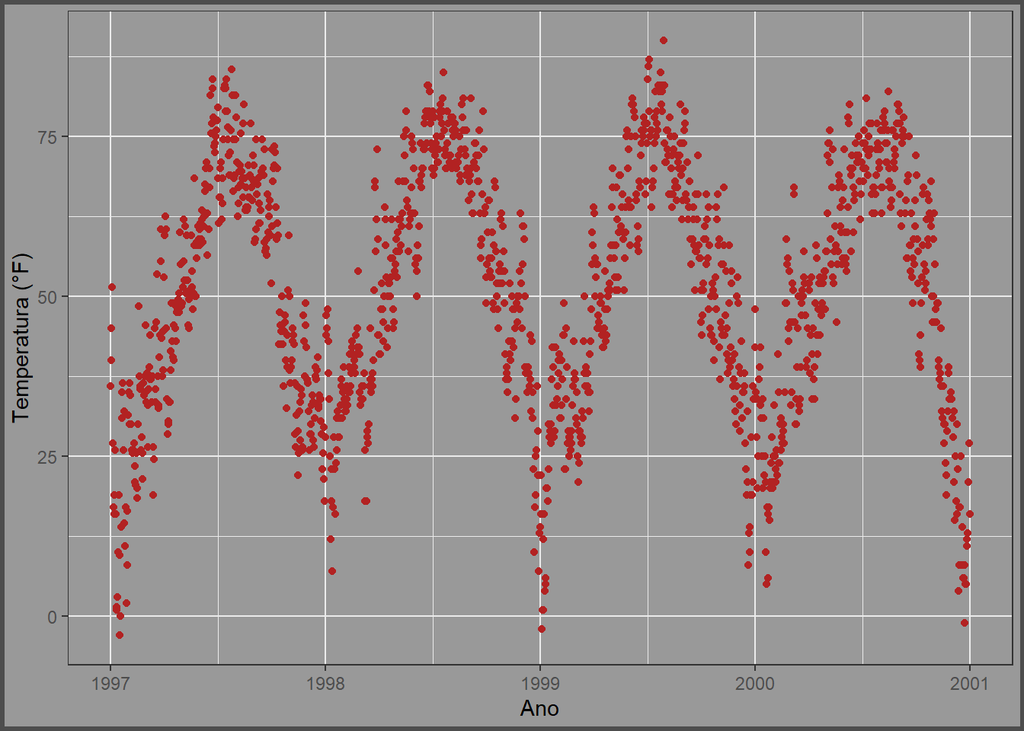

```r
ggplot(chic, aes(x = date, y = temp)) +
  geom_point(color = "firebrick") +
  labs(x = "Ano", y = "Temperatura (°F)") +
  theme(panel.background = element_rect(fill = NA),
        plot.background = element_rect(fill = "gray60",
                                       color = "gray30", size = 2))
```

Mais um exemplo

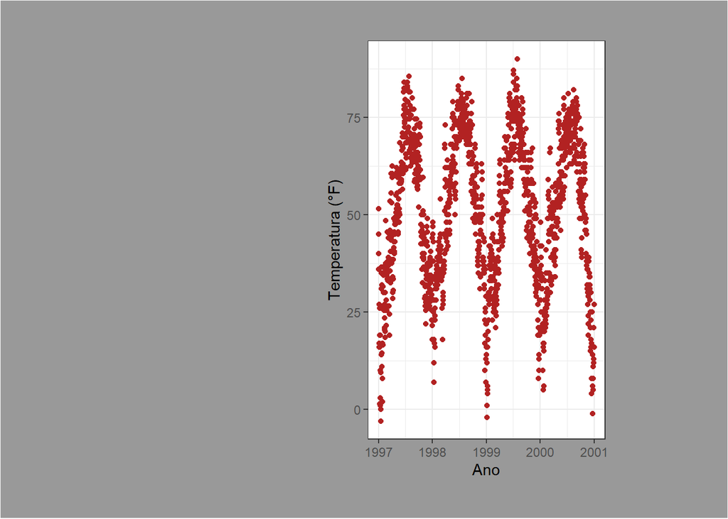

```r
ggplot(chic, aes(x = date, y = temp)) +
  geom_point(color = "firebrick") +
  labs(x = "Ano", y = "Temperatura (°F)") +
  theme(plot.background = element_rect(fill = "gray60"),
        plot.margin = margin(t = 1, r = 3, b = 1, l = 8, unit = "cm"))
```

## Fim :)

Espero que esse material tenha ajudado de alguma forma e fico à disposição para esclarecer o que for necessário.

## Check-out

### Que tal me ajudar a progredir?

Espero que esta atividade tenha sido produtiva e que possa ajudar na sua caminhada. Tomara que esse tenha sido um bom começo para seu aprendizado no universo R.

Se você puder, deixe sua opinião sobre este material no formulário anônimo [AQUI](https://forms.gle/RoSXAmNrXjaAFag4A). São só 5 perguntinhas que **não vão tomar muito seu tempo**, mas me ajudam muito a melhorar meu trabalho e saber se esse conteúdo está sendo útil.

Lembrando que o **formulário é anônimo**, não precisa se identificar se não quiser.

## Fim :)

Espero que esse material tenha ajudado de alguma forma e fico à disposição para esclarecer o que for necessário.

Dra. Fernanda Rodrigues de Avila https://avilaf.github.io/ fernandar.avila@gmail.com